# Light Temp Conditions

Sarah Postuma Douglas A. Campbell

# 1.0 Introduction

Mudflats are a bio-diverse, highly productive coastal and estuarine habitat home to microphytobenthic diatoms which carry out keystone functions and are responsible for 50% of estuarine primary productivity (Herlory et al., 2004). Motile microphytobenthic diatoms, predominantly pennate diatoms, engage in vertical migrations to the surface of mudflats, to carry out keystone functions during low tide and migrate back down during high tide (Conslavey et al., 2011). These migrations are asymmetrical, with diatoms migrating much quicker upwards than downwards to maximize light exposure for photosynthesis. Studies in estuaries around the world have shed light on these migratory patterns, however, no such studies have been performed in the rare habitat of the Bay of Fundy mudflats, located in The Bay of Fundy in New Brunswick. Fundy’s tides are the highest in the world due to an unusual combination of standing wave phenomena called seiche as well as the shape of the bay itself (Parks Canada Agency, 2023), with annual temperatures ranging from -14ºC to 10ºC (Corp, n.d). Our study aims to analyze the effects of temperature and light on the speed of vertical migration of microphytobenthic diatoms found in The Bay of Fundy, as well as their chlorophyll output under these conditions. We studied this phenomena to better understand the makeup of the Bay of Fundy and investigate the impacts of global warming. More broadly, to apply knowledge of this phenomena to satellite surveying of photosynthetic biomass and develop new methods of investigation. The goal for this particular project was to examine how vertical migration of benthic diatoms is controlled by increasing temperatures and high light condition.

## 1.1 Hypothesis

We hypothesize that cold temperatures and dark conditions will have an impact on microphytobenthic diatoms vertical migrations and chlorophyll output.

# 2.0 Methods

## 2.1 Mudflat Simulation

Three aluminum lasagna pans were filled with mudflat sediment from Peg’s Cove in the Bay of Fundy and excess water eliminated with a baster. The sediment was left moist.

## 2.2 Light and Temperature Samples

# 3.0 Data Analysis

### Loading Packages

```r
#install.packages("tidyverse", "knitr", "here", "ggplot2")
library(tidyverse)
library(knitr)
library(googlesheets4)
library(googledrive)
library(ggplot2)
```

### chl_data

Data is stored on Google docs and loads onto R Studio.

```r
gs4_deauth()
googlesheet_url <- "https://docs.google.com/spreadsheets/d/16DxWZhYw69ZgACGu82szN9tpgpYYPWIxPXOcSLM2Bo0/edit?usp=sharing"
chl_data <- read_sheet(googlesheet_url, sheet = "vert_migration")
```

```
## ✔ Reading from "Vertical Migration Data ".
```

```
## ✔ Range ''vert_migration''.
```

## 3.1 Set up data for analysis

Processing data for generating graphs.

### Transforming raw data fluorescence into Chl/cm^2

Instructions for the chlorophyll calculations come from CampbellSOP28ChlorophyllaTurner.pdf

```r
chl_data$Chl_ugL <- (chl_data$Fluorescence_Reading/7.0314) -0.9791
chl_data$Chl_ugcm2 <- (chl_data$Chl_ugL*chl_data$VolSol_mL/1000) / chl_data$Tissue_Area_cm2
kable(chl_data)
```

| OperatorID | SampleID | YYYYMMDDHHMM | Top_Bottom | Replicate | Temp_C | Light | Tissue_Area_cm2 | VolSol_mL | Fluorescence_Reading | Trial | …12 | …13 | …14 | …15 | …16 | …17 | …18 | …19 | Chl_ugL | Chl_ugcm2 |
| --- | --- | --- | --- | --- | --- | --- | --- | --- | --- | --- | --- | --- | --- | --- | --- | --- | --- | --- | --- | --- |
| NA | blank_1 | 202409260900 | NA | NA | NA | NA | NA | 2 | 0.18 | 1 | NA | NA | NA | NA | NA | NA | NA | Sarah start time 20C 9:23am | -0.9535005 | NA |
| GaCh | 3001 | 202409260900 | top | a | 23 | light | 4 | 2 | 157.47 | 1 | NA | NA | NA | NA | NA | NA | NA | Samples at pecks cove, not dense bloom | 21.4161556 | 0.0107081 |
| GaCh | 3002 | 202409260900 | bottom | a | 23 | light | 4 | 2 | 448.51 | 1 | NA | NA | NA | NA | NA | NA | NA | Chlorophyll should be similar | 62.8076281 | 0.0314038 |
| LiKa | 3003 | 202409261000 | top | a | 23 | light | 4 | 2 | 608.76 | 1 | NA | NA | NA | NA | NA | NA | NA | NA | 85.5982530 | 0.0427991 |
| LiKa | 3004 | 202409261000 | bottom | a | 23 | light | 4 | 2 | 1118.97 | 1 | NA | NA | NA | NA | NA | NA | NA | NA | 158.1599050 | 0.0790800 |
| LiKa | 3005 | 202409261130 | top | a | 23 | light | 4 | 4 | 933.48 | 1 | NA | NA | NA | NA | NA | NA | NA | NA | 131.7796678 | 0.1317797 |
| LiKa | 3006 | 202409261130 | bottom | a | 23 | light | 4 | 4 | 2282.57 | 1 | NA | NA | NA | NA | NA | NA | NA | NA | 323.6461524 | 0.3236462 |
| LiKa | 3007 | 202409261200 | top | a | 23 | light | 4 | 4 | 727.71 | 1 | NA | NA | NA | NA | NA | NA | NA | NA | 102.5152255 | 0.1025152 |
| LiKa | 3008 | 202409261200 | bottom | a | 23 | light | 4 | 4 | 1798.60 | 1 | NA | NA | NA | NA | NA | NA | NA | NA | 254.8163319 | 0.2548163 |
| LiKa | 3009 | 202409261300 | top | a | 23 | light | 4 | 2 | 955.85 | 1 | NA | NA | NA | NA | NA | NA | NA | NA | 134.9611111 | 0.0674806 |
| LiKa | 3010 | 202409261300 | bottom | a | 23 | light | 4 | 2 | 3898.50 | 1 | NA | NA | NA | NA | NA | NA | NA | NA | 553.4624052 | 0.2767312 |
| SaPo | 3011 | 202409261400 | top | a | 23 | light | 4 | 4 | 3107.16 | 1 | NA | NA | NA | NA | NA | NA | NA | NA | 440.9186728 | 0.4409187 |
| SaPo | 3012 | 202409261400 | bottom | a | 23 | light | 4 | 4 | 3619.61 | 1 | NA | NA | NA | NA | NA | NA | NA | NA | 513.7988958 | 0.5137989 |
| SaPo | blank_2 | 202409261400 | NA | NA | NA | NA | NA | NA | 0.19 | 1 | NA | NA | NA | NA | NA | NA | NA | NA | -0.9520784 | NA |
| SaPo | 1001 | 202409261400 | top | a | 23 | dark | 6 | 2 | 657.77 | 1 | NA | NA | NA | NA | NA | NA | NA | NA | 92.5684154 | 0.0308561 |
| SaPo | 1002 | 202409261400 | bottom | a | 23 | dark | 6 | 2 | 1831.68 | 1 | NA | NA | NA | NA | NA | NA | NA | NA | 259.5209427 | 0.0865070 |
| SaPo | 1003 | 202409261400 | top | a | 23 | med | 6 | 2 | 755.80 | 1 | NA | NA | NA | NA | NA | NA | NA | NA | 106.5101625 | 0.0355034 |
| SaPo | 1004 | 202409261400 | bottom | a | 23 | med | 6 | 2 | 2804.85 | 1 | NA | NA | NA | NA | NA | NA | NA | NA | 397.9243901 | 0.1326415 |
| SaPo | 1005 | 202409261400 | top | a | 23 | light | 6 | 2 | 3383.45 | 1 | NA | NA | NA | NA | NA | NA | NA | NA | 480.2124124 | 0.1600708 |
| SaPo | 1006 | 202409261400 | bottom | a | 23 | light | 6 | 2 | 3629.54 | 1 | NA | NA | NA | NA | NA | NA | NA | NA | 515.2111324 | 0.1717370 |
| SaPo | 1009 | 202410101430 | bottom | a | 15 | dark | 6 | 12 | 769.67 | 2 | NA | NA | NA | NA | NA | NA | NA | NA | 108.4827426 | 0.2169655 |
| SaPo | 1010 | 202410101430 | top | a | 15 | dark | 6 | 12 | 560.48 | 2 | NA | NA | NA | NA | NA | NA | NA | NA | 78.7319106 | 0.1574638 |
| SaPo | 1011 | 202410101430 | bottom | b | 15 | dark | 6 | 12 | 1413.95 | 2 | NA | NA | NA | NA | NA | NA | NA | NA | 200.1117212 | 0.4002234 |
| SaPo | 1014 | 202410101430 | top | c | 15 | dark | 6 | 12 | 927.44 | 2 | NA | NA | NA | NA | NA | NA | NA | NA | 130.9206639 | 0.2618413 |
| SaPo | 1015 | 202410101430 | bottom | d | 15 | dark | 6 | 4 | 1615.09 | 2 | NA | NA | NA | NA | NA | NA | NA | NA | 228.7176887 | 0.1524785 |
| SaPo | 1016 | 202410101430 | bottom | a | 15 | light | 6 | 4 | 1538.35 | 2 | NA | NA | NA | NA | NA | NA | NA | NA | 217.8037882 | 0.1452025 |
| SaPo | 1017 | 202410101430 | top | a | 15 | light | 6 | 12 | 1025.00 | 2 | NA | NA | NA | NA | NA | NA | NA | NA | 144.7955679 | 0.2895911 |
| SaPo | 1018 | 202410101430 | bottom | b | 15 | light | 6 | 12 | 1314.75 | 2 | NA | NA | NA | NA | NA | NA | NA | NA | 186.0035777 | 0.3720072 |
| SaPo | 1019 | 202410101430 | top | b | 15 | light | 6 | 12 | 687.76 | 2 | NA | NA | NA | NA | NA | NA | NA | NA | 96.8335689 | 0.1936671 |
| SaPo | 1020 | 202410101430 | bottom | c | 15 | light | 6 | 12 | 887.96 | 2 | NA | NA | NA | NA | NA | NA | NA | NA | 125.3058504 | 0.2506117 |

[output cut: 63 more lines]

### Sorting the data

```r
filtered_data <- filter(chl_data, Chl_ugcm2 > 0, YYYYMMDDHHMM %in% c(202410101430,
                                                                     202409261400))
filtered_data$Light_Temp <- factor(paste(filtered_data$Temp_C, filtered_data$Light))
```

### Top Bottom Ratio

Filtered_data_wide is created using pivot wider with the Top/Bottom ratios of Chl_ugcm2 Chlorophyll. The top and bottom chlorophyll are now in columns, which widens and shortens the dataframe. This makes the calculations easier to complete.

```r
filtered_data_wide <- filtered_data |>
  select(-c(Tissue_Area_cm2, VolSol_mL, Fluorescence_Reading, `...19`,  Chl_ugL)) |>
  pivot_wider(id_cols = c(YYYYMMDDHHMM, Replicate, Temp_C, Light), names_from = Top_Bottom, values_from = Chl_ugcm2, values_fn = mean) |>
  mutate(TopBottomRatio = top/bottom)
```

# 4.0 Results

## Figure 1: Temperature and Light Graph

The chlorophyll Chl_ugcm2 is plotted across 15°C, 20°C, and 23°C and different light conditions.

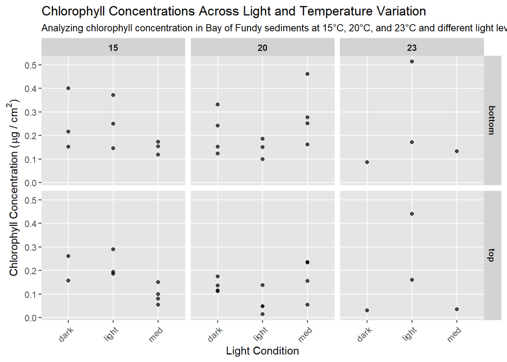

```r
filtered_data %>%
  ggplot() +
  geom_point(aes(x = Light, y = Chl_ugcm2), alpha = 0.7) +
  facet_grid(rows = vars(Top_Bottom), cols = vars(Temp_C)) +
  labs(
    x = "Light Condition",
    y = expression("Chlorophyll Concentration ("*mu*"g / cm"^2*")"),
    title = "Chlorophyll Concentrations Across Light and Temperature Variation",
    subtitle = "Analyzing chlorophyll concentration in Bay of Fundy sediments at 15°C, 20°C, and 23°C and different light levels"

  ) +
  theme(axis.text.x = element_text(angle = 45, vjust = 1, hjust = 1),
    plot.subtitle = element_text(size = 9.8),
    panel.background = element_rect(fill = "gray90"),
    panel.grid.major = element_line(color = "white"),
    panel.grid.minor = element_blank(),
    strip.background = element_rect(fill = "lightgray"),
    strip.text = element_text(face = "bold"))
```

## Figure 2: Top Bottom Ratio Graph

The Top/Bottom ratio is analyzed with the variables of 15°C, 20°C, and 23°C and the different light conditions.

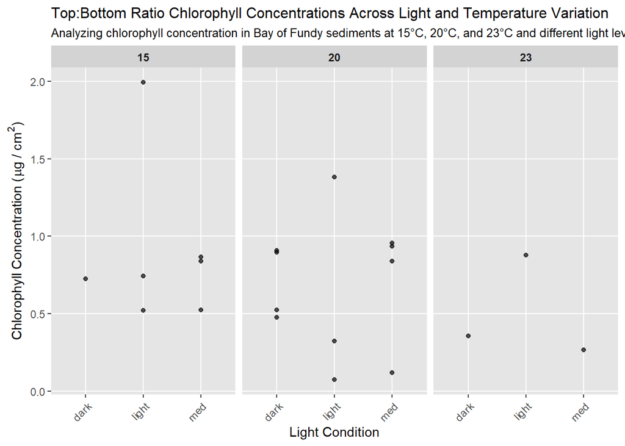

```r
filtered_data_wide %>%
  ggplot() +
  geom_point(aes(x = Light, y = TopBottomRatio), alpha = 0.7) +
  facet_wrap(vars(Temp_C)) +
  labs(
    x = "Light Condition",
    y = expression("Chlorophyll Concentration ("*mu*"g / cm"^2*")"),
    title = "Top:Bottom Ratio Chlorophyll Concentrations Across Light and Temperature Variation",
    subtitle = "Analyzing chlorophyll concentration in Bay of Fundy sediments at 15°C, 20°C, and 23°C and different light levels"

  ) +
  theme(axis.text.x = element_text(angle = 45, vjust = 1, hjust = 1),
    plot.title = element_text(size = 12),
    plot.subtitle = element_text(size = 9.8),
    panel.background = element_rect(fill = "gray90"),
    panel.grid.major = element_line(color = "white"),
    panel.grid.minor = element_blank(),
    strip.background = element_rect(fill = "lightgray"),
    strip.text = element_text(face = "bold"))
```

## Anova on Top:Bottom Ratios, Temperature and Light Conditon

A two factor anova is run on the TopBottomRatio on light conditions and the temperatures 15°C, 20°C, and 23°C.

```r
summary(aov(TopBottomRatio ~ Light * Temp_C,
           data =  filtered_data_wide))
```

```
##              Df Sum Sq Mean Sq F value Pr(>F)
## Light         2  0.162 0.08110   0.373  0.695
## Temp_C        1  0.310 0.30973   1.423  0.251
## Light:Temp_C  2  0.015 0.00742   0.034  0.967
## Residuals    15  3.265 0.21764
## 5 observations deleted due to missingness
```

### Interpretation:

No significance was found for light conditon, temperature, or both on the top to bottom ratio.

# 5.0 Conclusion

# 6.0 References

Conslavey, M., Paterson, D. M., & Underwood, G. J. C. (2011). The Ups and Downs of Life in a Benthic Biofilm: Migration of Benthic Diatoms. Diatom Research, 19:2(181–202). https://doi.org/10.1080/0269249X.2004.9705870  
Daggers, T. D., Kromkamp, J. C., Herman, P. M. J., & van der Wal, D. (2018). A model to assess microphytobenthic primary production in tidal systems using satellite remote sensing. Remote Sensing of Environment, 211, 129–145. https://doi.org/10.1016/j.rse.2018.03.037  
Haro, S., Bohórquez, J., Lara, M., Garcia-Robledo, E., González, C. J., Crespo, J. M., Papaspyrou, S., & Corzo, A. (2019). Diel patterns of microphytobenthic primary production in intertidal sediments: The role of photoperiod on the vertical migration circadian rhythm. Scientific Reports, 9(1), 13376. https://doi.org/10.1038/s41598-019-49971-8  
Herlory, O., Guarini, J.-M., Richard, P., & Blanchard, G. F. (2004). Microstructure of microphytobenthic biofilm and its spatio-temporal dynamics in an intertidal mudflat (Aiguillon Nay, France). Marine Ecology Progress Series, 282(33–44). https://doi.org/10.3354/meps282033  
Corp, P. (n.d.). Attractions: Historical. The Weather Network. Retrieved September 13, 2024, from https://www.theweathernetwork.com/ca/forecasts/attractions/historical/nova-scotia/bay-of-fundy-tourism